# Equations of Straight Line Graphs - Part 1

06 April, 2022

### KS3: Drawing and finding the equations of straight line graphs (y=mx+c)

### Lesson objectives

Plotting straight line graphs y=mx+c

### Packages used in this lesson:

- `tidyverse`

### Success criteria

- Plot a straight line graph y = mx+c
- Compare graphs

### Keywords

- slope
- gradient = m
- intercept = c
- x-axis
- y-axis

### Remember

Knit your document often to check the output.

Make sure you do a final knit at the end of the lesson

#### Worked Example 1

This is a worked example for you to follow.

We will show you how to plot the line graph for y=2x + 5.

Run the code by clicking on the little arrow to the right of the code chunk.

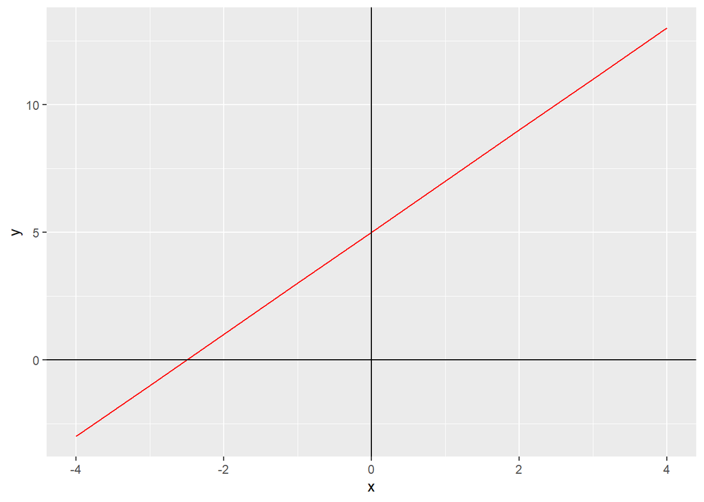

```r
x <- seq(from=-4, to=4, by=1) # sequence the x-axis from -4 to 4
y <- 2*x+5
mydata <- tibble (x,y)
ggplot(mydata) +
  aes(x,y) +
  geom_line (col='red')+
  geom_vline (xintercept = 0, col='black')+
  geom_hline (yintercept = 0, col='black')
```

Now close the image by clicking on the X to the right of the graph

#### Activity1:

Write your own code to draw the following graphs.

Use code chunk1 from the example above to help you.

1. y = 2x (in code chunk2)
2. y = 3x + 10 (in code chunk3)
3. y = 5x + 2.5 (in code chunk4)

#### Worked Example 2

Drawing more than one line on a graph helps us to compare the lines and see what is the same and what is different. Here is a worked example for four different lines.

1. y=3x+0
2. y=3x+1
3. y=3x+2
4. y=3x+3

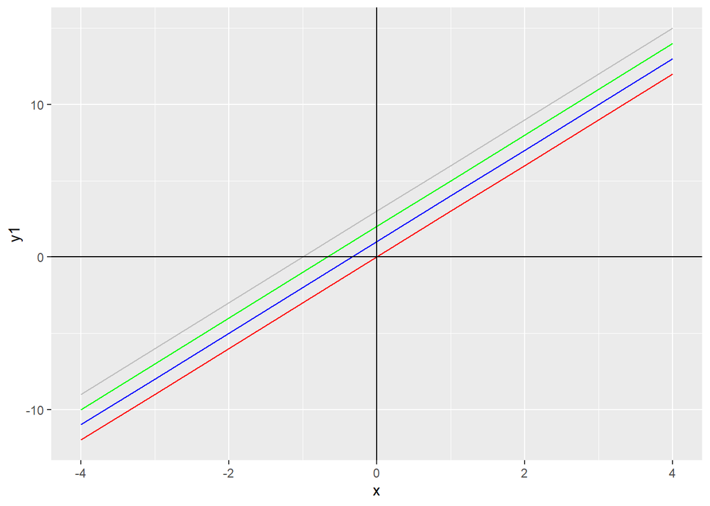

```r
x <- seq(-4, 4) # sequence from -4 to 4
y1 <- 3*x+0
y2 <- 3*x+1
y3 <- 3*x+2
y4 <- 3*x+3
mydata <- tibble (x,y1,y2,y3,y4)
ggplot(mydata) +
  geom_line (aes(x=x, y=y1), col='red')+
  geom_line (aes(x=x, y=y2), col='blue')+
  geom_line (aes(x=x, y=y3), col='green')+
  geom_line (aes(x=x, y=y4), col='grey') +
  geom_vline (xintercept = 0, col='black')+
  geom_hline (yintercept = 0, col='black')
```

Question: From the graph what looks the same and what looks different about these lines?

Answer:

#### Activity2:

Draw the following lines on a graph

1. y=1x+5
2. y=2x+5
3. y=3x+5
4. y=4x+5

Use code chunk5 from the example above to help you. Remember to update the R code with the new lines.

Run the code. Knit the document.

Question: What is the same and what is different about the lines?

Answer: